# Hydroshare_wet_dry_summary

Tyler Moore

2026-08-06

## Introduction

The purpose of this report is to show how dry the monitoring sites were for the AIMS Hydroshare project, as well as to identify the driest sites overall, and the driest sites on average.

## Data

Data was downloaded from the [Hydroshare Website](https://www.hydroshare.org/home/) from both publicly available data and some non-public-facing datasets. All data were stored in a local folder.

One change was made in the data file for the data from the Oka’ Yanahli (OK) site in order to make reading the data simpler. The column name for site ID was updated from “siteID” to “siteId” to match all other datasets being analyzed.

Once the data had been read in I then transformed the data to extract the region and watershed where the data was collected.

From there I then computed the average amount of time each sensor recorded wet versus dry during each day as a mean. The purpose was to condense the data into a single point per day per site.

## Results

**Top 5 Hydrological Observations with the Highest Annual Dry Days**

Summary of the driest site-year combinations across monitored watersheds

| Site ID | Region | Watershed | Year | Annual Dry Days |
| --- | --- | --- | --- | --- |
| 20M01 | GP | KNZ | 2023 | 349 |
| 20M02 | GP | KNZ | 2023 | 342 |
| 02M02 | GP | KNZ | 2023 | 334 |
| 04T01 | GP | KNZ | 2024 | 333 |
| 04M11 | GP | KNZ | 2022 | 330 |

The next table displays the overall driest sites on average for all data collected.

**Top 5 Monitored Sites with the Highest Mean Annual Dry Days**

Summary of the driest sites on average across monitored watersheds

| Site ID | Region | Watershed | Mean Annual Dry Days |
| --- | --- | --- | --- |
| SHB01 | GP | SHN | 277 |
| 02M02 | GP | KNZ | 264 |
| SHM03 | GP | SHN | 256 |
| STIC04 | MW | GBJ | 254 |
| SHC03 | GP | SHN | 252 |

The following heatmaps show the number of dry days for each site in the given year. The sites where there is no reported data in the given year are shown in white.

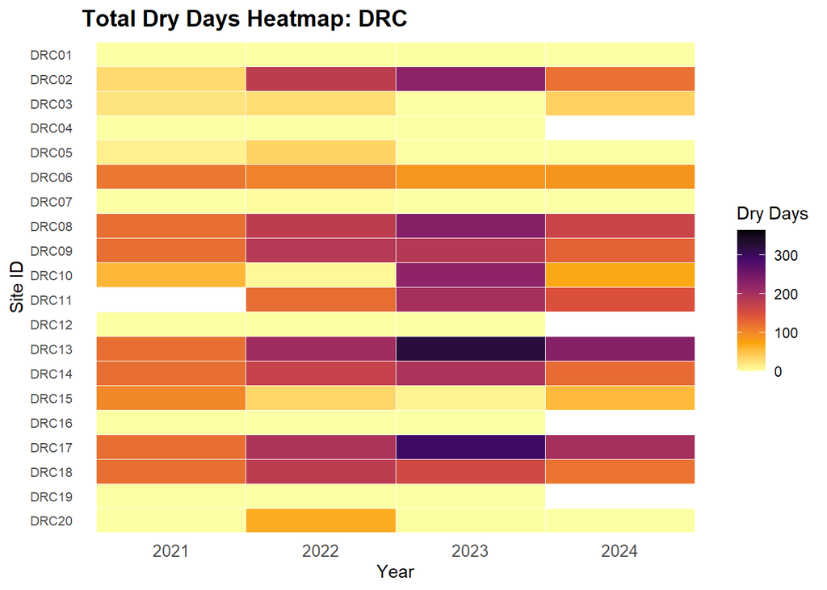

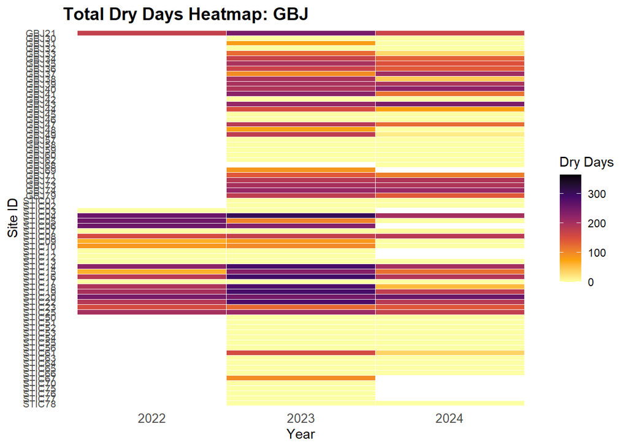

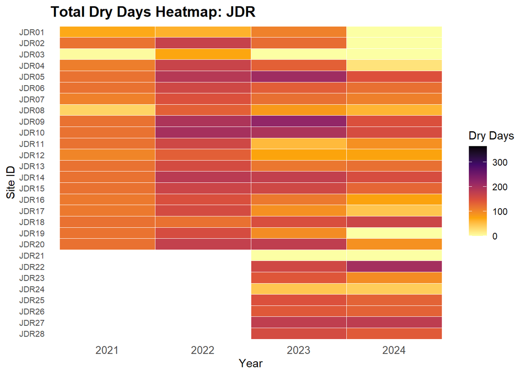

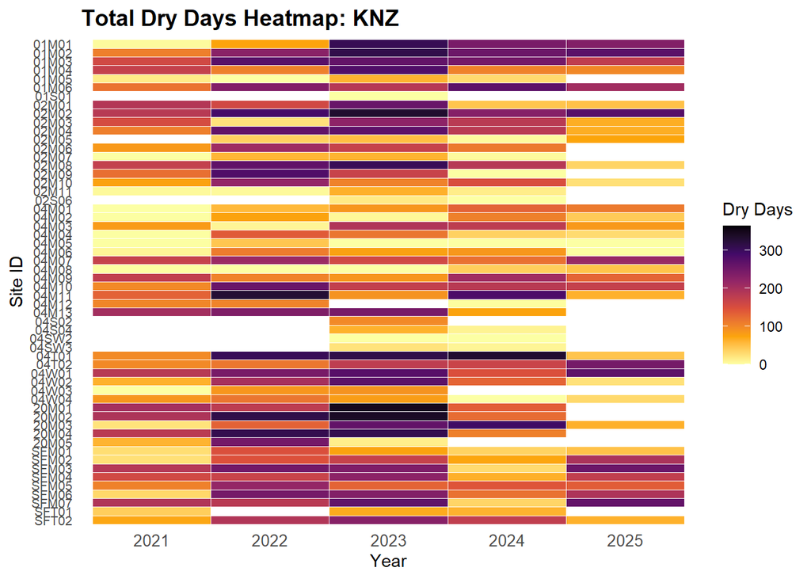

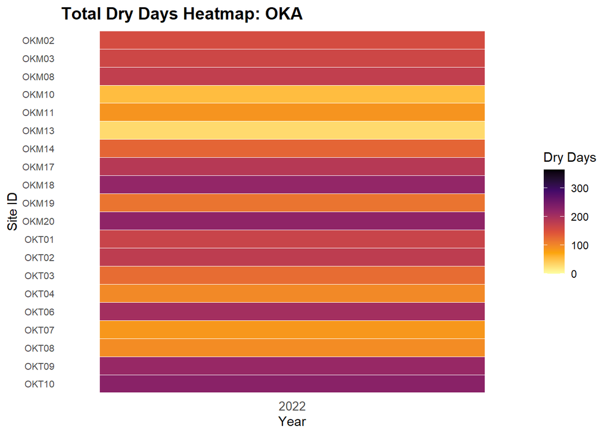

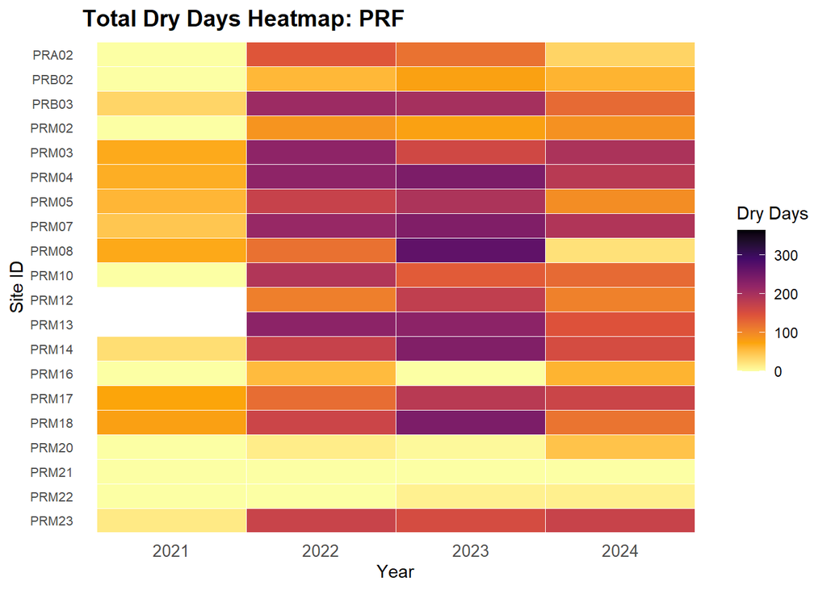

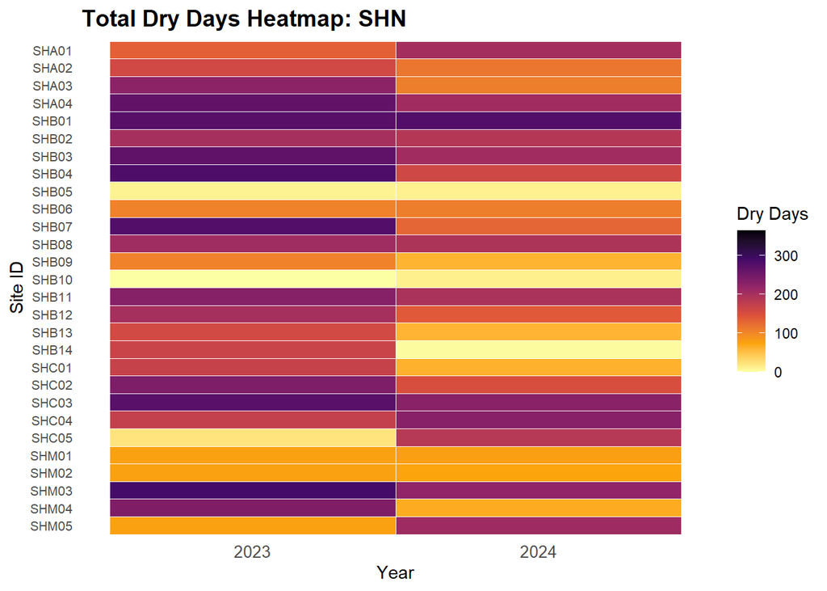

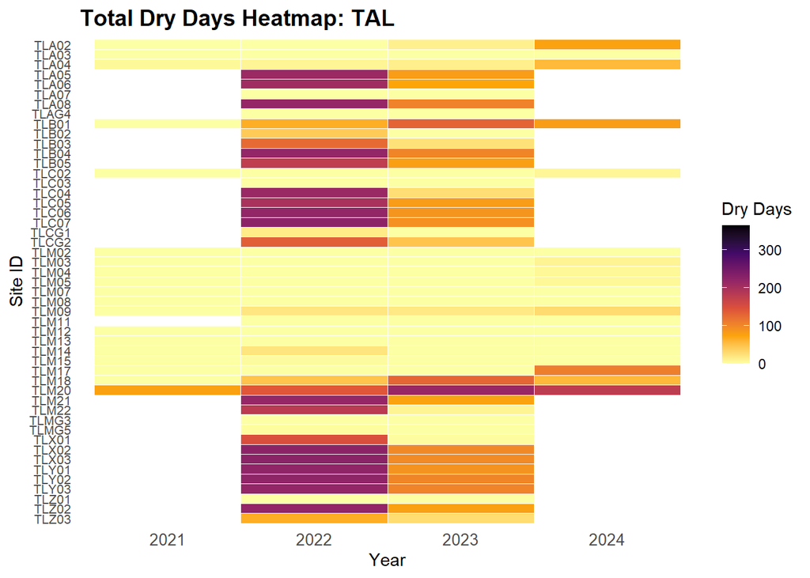

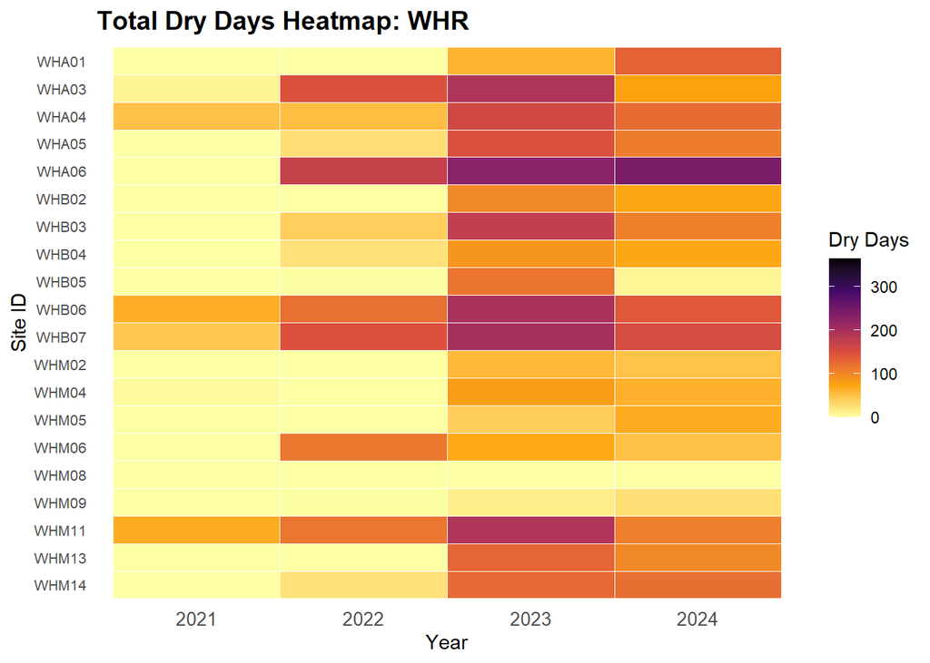

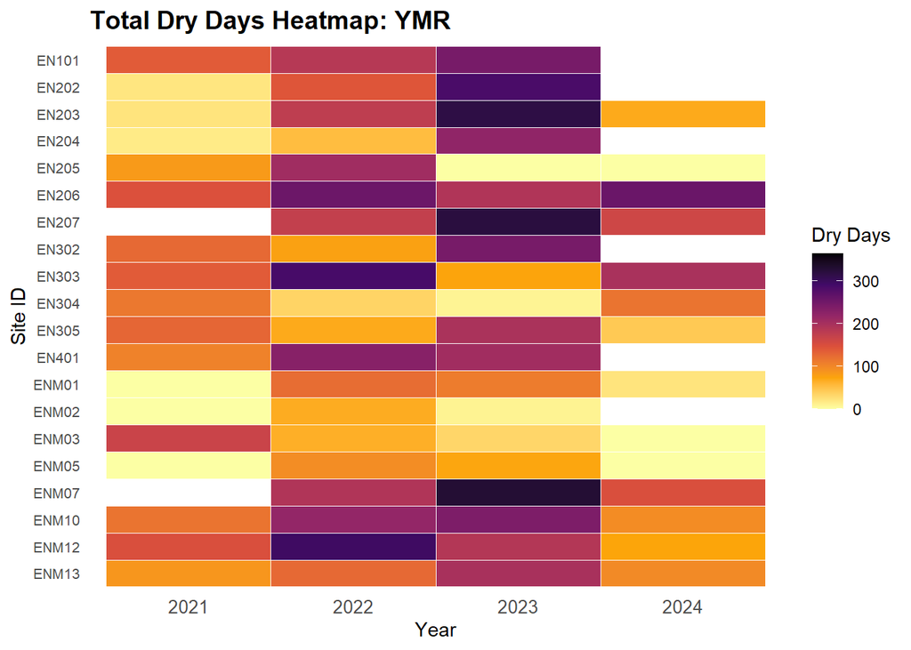